# 26 - Class Notes

Fadel M Megahed

April 28, 2021

# 1 Recap of What we Learned Last Class

1. Use regression to account for seasonality in a time series.
2. Compare the performance of the regression model with that obtained from `auto.arima()`.

## 1.1 Required Packages

In the code chunk below, we use the `pacman` package to load the required packages and install them if necessary.

```r
if(require(pacman)==FALSE) install.packages("pacman")
```

```r
pacman::p_load(tidyverse,
               magrittr, # for the two-way pipe
               fpp2, # accuracy() function, Arima(), auto.arima(),
               astsa, # package is for the required data
               plotly, # for interactive graphs
               ggpubr)

source('https://raw.githubusercontent.com/fmegahed/businessForecasting/master/lectures/24%20-%20Time%20Series%20Regression%20(Cont)/resPlotTS.R') # loading our resPlot function from Last Class
```

## 1.2 Main Learning Outcomes for Today’s Class

1. Combine regression with ARIMA models to model a time series with autocorrelated errors.
2. Use the xreg argument to combine ARIMA models with regression predictors.

# 2 Combining Regression with ARIMA Models

## 2.1 Preface

We have learned to fit ARIMA models to predict a series from itself, removing the autocorrelation from a series. These methods are useful, but don’t allow us to combine “outside” information to boost our forecast.

Now we will discuss combining regression (**outside information**) and ARIMA models (inside information) to forecast a time series.

A multiple regression model takes on the form:
$$Y_t = \beta_0 + \beta_1 x_{t,1} + \beta_2 x_{t,2} + \dots + \beta_q x_{t,q} + \epsilon_t,$$
where we typically assume that $\epsilon_t$ is independent, identically distributed white noise (normally distributed).

## 2.2 What we Learned from the J&J Example

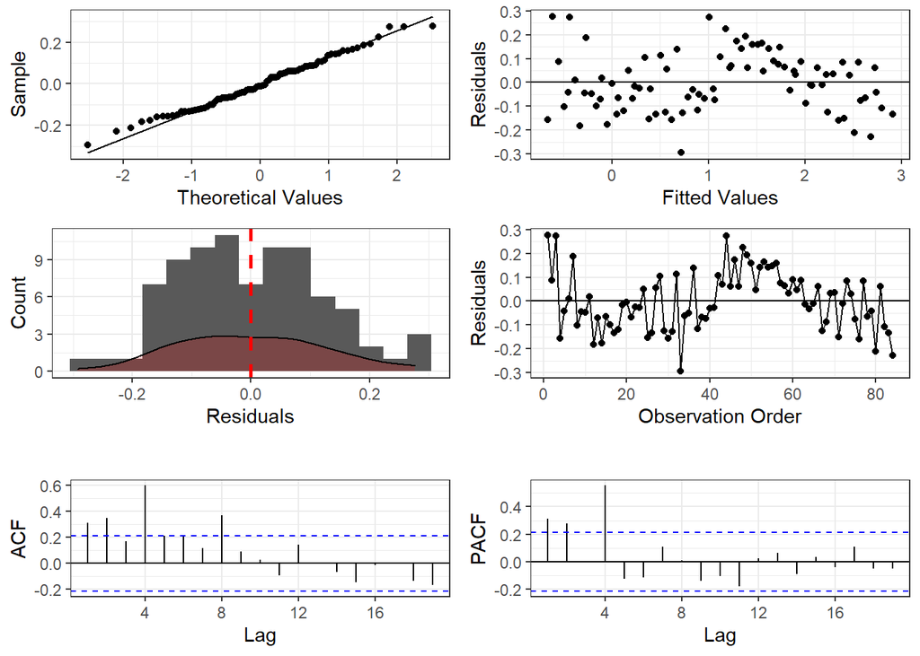

```r
log_jj = log(jj) # to make the data more linear and stablize the variance a bit
t = time(log_jj) # capture/create a time index

model4 = tslm(log_jj ~ trend + season) # fitting a regression model with season and trend

modelSummary = summary(model4) # saving the summary output into the object modelSummary

resplot(res = model4$residuals, fit = model4$fitted.values) # visualizing the residuals and fitted values
```

**Based on the J&J Example**, when our dependent and independent variables are observed over time, $\epsilon_t$ is often correlated over time. **Hence, the assumptions of iid residuals are not met and the fitted regression models should not be used.**

## 2.3 Possible Solution

Thus, we will restate our model as follows:
$$Y_t = \beta_0 + \beta_1 x_{t,1} + \beta_2 x_{t,2} + \dots + \beta_q x_{t,q} + \eta_t,$$
where $\eta_t$ **follows an ARIMA model.**

## 2.4 Using R to Fit The Model

We will use the “uschange” data from the `fpp2` package to forecast changes in personal consumption expenditures based on personal disposable income from 1970 to 2016.

**Process:**

# 3 In-Class Activities

1. Compare the results from the class example, with the following three models:  
   (a) auto.arima using only the Y series.  
   (b) autoarima using two explanatory variables (“Income” and “Savings”).  
   (c) lm using both income and savings.
2. Which models are suitable? (i.e., the assumptions about the model residuals are met).
3. Among the suitable models, pick the best model.